# ----------------------------------------- Mohamed Mady -----------------------------------------

# ------------------------------ Airline Passengers Satisfaction ------------------------------

### ---------- Data Preprocessing, Exploratory Data Analysis, and Machine Learning Classification Models ----------

[figure not shown]

# Dataset Description

- ID: Unique passenger identifier
- Gender: Gender of the passenger (Male/Female)
- Age: Age of the passenger
- Customer Type: Type of airline customer (First-time/Returning)
- Type of Travel: Purpose of the flight (Business/Personal)
- Class: Travel class in the airplane for the passenger seat
- Flight Distance: Flight distance in miles
- Departure Delay: Flight departure delay in minutes
- Arrival Delay: Flight arrival delay in minutes
- Departure and Arrival Time Convenience: Satisfaction level with the convenience of the flight departure and arrival times from 1 (lowest) to 5 (highest)
- Ease of Online Booking: Satisfaction level with the online booking experience from 1 (lowest) to 5 (highest)
- Check-in Service: Satisfaction level with the check-in service from 1 (lowest) to 5 (highest)
- Online Boarding: Satisfaction level with the online boarding experience from 1 (lowest) to 5 (highest)
- Gate Location: Satisfaction level with the gate's location in the airport from 1 (lowest) to 5 (highest)
- On-board Service: Satisfaction level with the on-boarding service in the airport from 1 (lowest) to 5 (highest)
- Seat Comfort: Satisfaction level with the comfort of the airplane seat from 1 (lowest) to 5 (highest)
- Leg Room Service: Satisfaction level with the leg room of the airplane seat from 1 (lowest) to 5 (highest)
- Cleanliness: Satisfaction level with the cleanliness of the airplane from 1 (lowest) to 5 (highest)
- Food and Drink: Satisfaction level with the food and drinks on the airplane from 1 (lowest) to 5 (highest)
- In-flight Service: Satisfaction level with the in-flight service from 1 (lowest) to 5 (highest)
- In-flight Wifi Service: Satisfaction level with the in-flight Wifi service from 1 (lowest) to 5 (highest)
- In-flight Entertainment: Satisfaction level with the in-flight entertainment from 1 (lowest) to 5 (highest)
- Baggage Handling: Satisfaction level with the baggage handling from the airline from 1 (lowest) to 5 (highest)
- Overall Satisfaction Points: Sum of all satisfaction levels
- Satisfaction: Overall satisfaction level with the airline (Satisfied/Neutral or unsatisfied)

```python
# Importing Libraries
import numpy as np
import pandas as pd
import matplotlib.pyplot as plt
import seaborn as sns
```

```python
# Loading the dataset to a data frame
df = pd.read_csv('airline_passenger_satisfaction.csv')
```

```python
# Showing the head of the data frame
df.head()
```

|  | ID | Gender | Age | Customer Type | Type of Travel | Class | Flight Distance | Departure Delay | Arrival Delay | Departure and Arrival Time Convenience | ... | Seat Comfort | Leg Room Service | Cleanliness | Food and Drink | In-flight Service | In-flight Wifi Service | In-flight Entertainment | Baggage Handling | Overall Satisfaction Points | Satisfaction |
| --- | --- | --- | --- | --- | --- | --- | --- | --- | --- | --- | --- | --- | --- | --- | --- | --- | --- | --- | --- | --- | --- |
| 0 | 1 | Male | 48 | First-time | Business | Business | 821 | 2 | 5.0 | 3 | ... | 5 | 2 | 5 | 5 | 5 | 3 | 5 | 5 | 54 | Neutral or Dissatisfied |
| 1 | 2 | Female | 35 | Returning | Business | Business | 821 | 26 | 39.0 | 2 | ... | 4 | 5 | 5 | 3 | 5 | 2 | 5 | 5 | 53 | Satisfied |
| 2 | 3 | Male | 41 | Returning | Business | Business | 853 | 0 | 0.0 | 4 | ... | 5 | 3 | 5 | 5 | 3 | 4 | 3 | 3 | 55 | Satisfied |
| 3 | 4 | Male | 50 | Returning | Business | Business | 1905 | 0 | 0.0 | 2 | ... | 5 | 5 | 4 | 4 | 5 | 2 | 5 | 5 | 53 | Satisfied |
| 4 | 5 | Female | 49 | Returning | Business | Business | 3470 | 0 | 1.0 | 3 | ... | 4 | 4 | 5 | 4 | 3 | 3 | 3 | 3 | 49 | Satisfied |

5 rows × 25 columns

```python
# Showing the shape of the data frame
df.shape
```

```
(129880, 25)
```

```python
# Showing the columns of the data frame
df.columns
```

```
Index(['ID', 'Gender', 'Age', 'Customer Type', 'Type of Travel', 'Class',
       'Flight Distance', 'Departure Delay', 'Arrival Delay',
       'Departure and Arrival Time Convenience', 'Ease of Online Booking',
       'Check-in Service', 'Online Boarding', 'Gate Location',
       'On-board Service', 'Seat Comfort', 'Leg Room Service', 'Cleanliness',
       'Food and Drink', 'In-flight Service', 'In-flight Wifi Service',
       'In-flight Entertainment', 'Baggage Handling',
       'Overall Satisfaction Points', 'Satisfaction'],
      dtype='object')
```

```python
# Selecting the columns to work on
df = df[['Gender', 'Age', 'Customer Type', 'Type of Travel', 'Class', 'Flight Distance', 'Departure Delay', 'Arrival Delay',
         'Departure and Arrival Time Convenience', 'Ease of Online Booking', 'Check-in Service', 'Online Boarding',
         'Gate Location', 'On-board Service', 'Seat Comfort', 'Leg Room Service', 'Cleanliness', 'Food and Drink',
         'In-flight Service', 'In-flight Wifi Service', 'In-flight Entertainment', 'Baggage Handling',
         'Overall Satisfaction Points', 'Satisfaction']]
```

```python
# Showing some information about the data frame
df.info()
```

```
<class 'pandas.core.frame.DataFrame'>
RangeIndex: 129880 entries, 0 to 129879
Data columns (total 24 columns):
 #   Column                                  Non-Null Count   Dtype
---  ------                                  --------------   -----
 0   Gender                                  129880 non-null  object
 1   Age                                     129880 non-null  int64
 2   Customer Type                           129880 non-null  object
 3   Type of Travel                          129880 non-null  object
 4   Class                                   129880 non-null  object
 5   Flight Distance                         129880 non-null  int64
 6   Departure Delay                         129880 non-null  int64
 7   Arrival Delay                           129487 non-null  float64
 8   Departure and Arrival Time Convenience  129880 non-null  int64
 9   Ease of Online Booking                  129880 non-null  int64
```

[output cut: 16 more lines]

```python
# Checking if there're any null values
df.isnull().sum()
```

```
Gender                                      0
Age                                         0
Customer Type                               0
Type of Travel                              0
Class                                       0
Flight Distance                             0
Departure Delay                             0
Arrival Delay                             393
Departure and Arrival Time Convenience      0
Ease of Online Booking                      0
Check-in Service                            0
Online Boarding                             0
Gate Location                               0
On-board Service                            0
Seat Comfort                                0
Leg Room Service                            0
Cleanliness                                 0
Food and Drink                              0
In-flight Service                           0
In-flight Wifi Service                      0
In-flight Entertainment                     0
Baggage Handling                            0
Overall Satisfaction Points                 0
Satisfaction                                0
dtype: int64
```

```python
# Showing some Information describing the data frame
df['Arrival Delay'].describe()
```

```
count    129487.000000
mean         15.091129
std          38.465650
min           0.000000
25%           0.000000
50%           0.000000
75%          13.000000
max        1584.000000
Name: Arrival Delay, dtype: float64
```

```python
# Filling all null values in the Arrival Delay column with the mean value of the column
df['Arrival Delay'] = df['Arrival Delay'].fillna(df['Arrival Delay'].mean())
```

```python
# Converting the data type of the Arrival Delay column to integer
df['Arrival Delay'] = df['Arrival Delay'].astype(int)
```

```python
# Showing some information about the data frame
df.info()
```

```
<class 'pandas.core.frame.DataFrame'>
RangeIndex: 129880 entries, 0 to 129879
Data columns (total 24 columns):
 #   Column                                  Non-Null Count   Dtype
---  ------                                  --------------   -----
 0   Gender                                  129880 non-null  object
 1   Age                                     129880 non-null  int64
 2   Customer Type                           129880 non-null  object
 3   Type of Travel                          129880 non-null  object
 4   Class                                   129880 non-null  object
 5   Flight Distance                         129880 non-null  int64
 6   Departure Delay                         129880 non-null  int64
 7   Arrival Delay                           129880 non-null  int32
 8   Departure and Arrival Time Convenience  129880 non-null  int64
 9   Ease of Online Booking                  129880 non-null  int64
```

[output cut: 16 more lines]

```python
# Showing some Information describing the data frame
df.describe()
```

|  | Age | Flight Distance | Departure Delay | Arrival Delay | Departure and Arrival Time Convenience | Ease of Online Booking | Check-in Service | Online Boarding | Gate Location | On-board Service | Seat Comfort | Leg Room Service | Cleanliness | Food and Drink | In-flight Service | In-flight Wifi Service | In-flight Entertainment | Baggage Handling | Overall Satisfaction Points |
| --- | --- | --- | --- | --- | --- | --- | --- | --- | --- | --- | --- | --- | --- | --- | --- | --- | --- | --- | --- |
| count | 129880.000000 | 129880.000000 | 129880.000000 | 129880.000000 | 129880.000000 | 129880.000000 | 129880.000000 | 129880.000000 | 129880.000000 | 129880.000000 | 129880.000000 | 129880.000000 | 129880.000000 | 129880.000000 | 129880.000000 | 129880.000000 | 129880.000000 | 129880.000000 | 129880.000000 |
| mean | 39.427957 | 1190.316392 | 14.713713 | 15.090853 | 3.057599 | 2.756876 | 3.306267 | 3.252633 | 2.976925 | 3.383023 | 3.441361 | 3.350878 | 3.286326 | 3.204774 | 3.642193 | 2.728696 | 3.358077 | 3.632114 | 45.377741 |
| std | 15.119360 | 997.452477 | 38.071126 | 38.407410 | 1.526741 | 1.401740 | 1.266185 | 1.350719 | 1.278520 | 1.287099 | 1.319289 | 1.316252 | 1.313682 | 1.329933 | 1.176669 | 1.329340 | 1.334049 | 1.180025 | 9.264191 |
| min | 7.000000 | 31.000000 | 0.000000 | 0.000000 | 0.000000 | 0.000000 | 0.000000 | 0.000000 | 0.000000 | 0.000000 | 0.000000 | 0.000000 | 0.000000 | 0.000000 | 0.000000 | 0.000000 | 0.000000 | 1.000000 | 15.000000 |
| 25% | 27.000000 | 414.000000 | 0.000000 | 0.000000 | 2.000000 | 2.000000 | 3.000000 | 2.000000 | 2.000000 | 2.000000 | 2.000000 | 2.000000 | 2.000000 | 2.000000 | 3.000000 | 2.000000 | 2.000000 | 3.000000 | 39.000000 |
| 50% | 40.000000 | 844.000000 | 0.000000 | 0.000000 | 3.000000 | 3.000000 | 3.000000 | 3.000000 | 3.000000 | 4.000000 | 4.000000 | 4.000000 | 3.000000 | 3.000000 | 4.000000 | 3.000000 | 4.000000 | 4.000000 | 46.000000 |
| 75% | 51.000000 | 1744.000000 | 12.000000 | 13.000000 | 4.000000 | 4.000000 | 4.000000 | 4.000000 | 4.000000 | 4.000000 | 5.000000 | 4.000000 | 4.000000 | 4.000000 | 5.000000 | 4.000000 | 4.000000 | 5.000000 | 52.000000 |
| max | 85.000000 | 4983.000000 | 1592.000000 | 1584.000000 | 5.000000 | 5.000000 | 5.000000 | 5.000000 | 5.000000 | 5.000000 | 5.000000 | 5.000000 | 5.000000 | 5.000000 | 5.000000 | 5.000000 | 5.000000 | 5.000000 | 70.000000 |

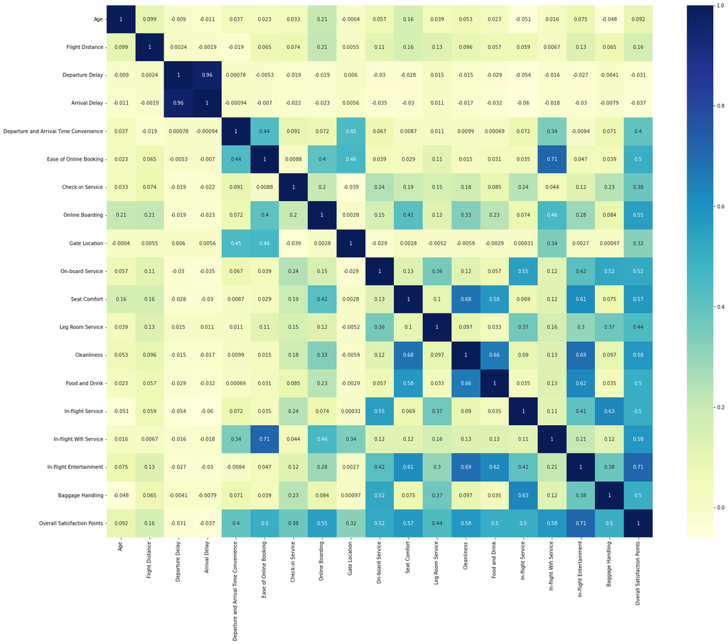

```python
# Plotting a heatmap to show the correlation between features
plt.figure(figsize = (25,20))
sns.heatmap(df.corr(), annot = True , cmap = "YlGnBu");
```

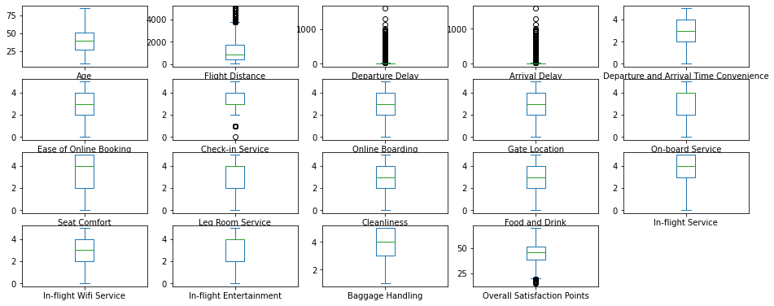

```python
# Plotting box plots to determine the outliers in each feature
df.plot(kind = 'box', subplots = True, layout = (5,5), figsize = (16,8));
```

```python
# Checking if there're any duplicates
df.duplicated().sum()
```

```
0
```

```python
# Showing the columns of the data frame
df.columns
```

```
Index(['Gender', 'Age', 'Customer Type', 'Type of Travel', 'Class',
       'Flight Distance', 'Departure Delay', 'Arrival Delay',
       'Departure and Arrival Time Convenience', 'Ease of Online Booking',
       'Check-in Service', 'Online Boarding', 'Gate Location',
       'On-board Service', 'Seat Comfort', 'Leg Room Service', 'Cleanliness',
       'Food and Drink', 'In-flight Service', 'In-flight Wifi Service',
       'In-flight Entertainment', 'Baggage Handling',
       'Overall Satisfaction Points', 'Satisfaction'],
      dtype='object')
```

```python
def func(pct, allvalues):
    absolute = int(pct / 100.*np.sum(allvalues))
    return "{:.1f}%\n({:d})".format(pct, absolute)
```

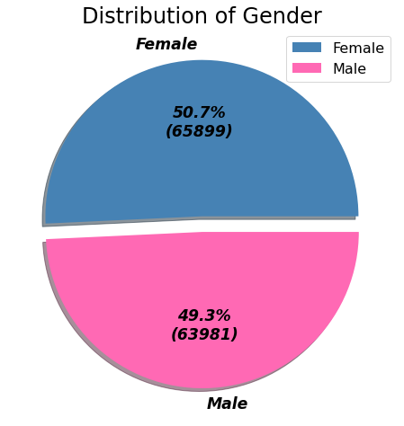

```python
fig, ax = plt.subplots(figsize = (12, 8))
Gender = df.Gender.value_counts()
ax.pie(Gender.values, labels = Gender.index, explode=[0.05, 0.05], shadow = True, colors = ['steelblue', 'hotpink'],
       autopct = lambda pct: func(pct, Gender.values),
       textprops = {'family':'sans-serif', 'fontsize':'xx-large', 'fontstyle':'italic', 'fontweight':'heavy'})
plt.title('Distribution of Gender', size = 24)
plt.legend(Gender.index, loc = 'upper right', prop={'size': 16})
plt.show()
```

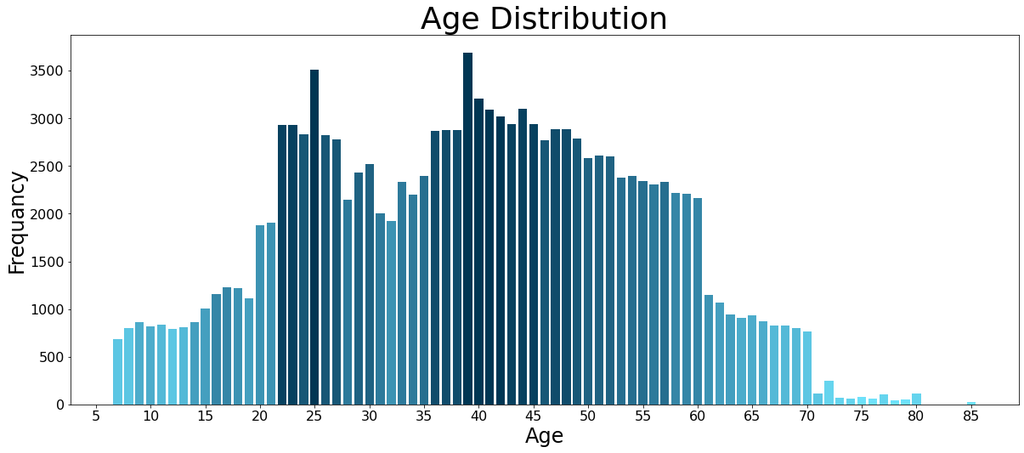

```python
fig, ax = plt.subplots(figsize = (20, 8))
Age = df.Age.value_counts().sort_index()
ax.bar(Age.index, Age.values, color = ['#5cc6e3', '#5cc6e3', '#4caccb', '#4caccb', '#54b9d7', '#5cc6e3', '#54b9d7', '#449fbf',
                                       '#449fbf', '#3586a7', '#3586a7', '#3c93b3', '#449fbf', '#3c93b3', '#3c93b3', '#07415f',
                                       '#07415f', '#175776', '#003653', '#175776', '#175776', '#2d7a9b', '#1f6282', '#1f6282',
                                       '#2d7a9b', '#3c93b3', '#2d7a9b', '#2d7a9b', '#266e8f', '#104c6b', '#104c6b', '#104c6b',
                                       '#003653', '#003653', '#003653', '#003653', '#07415f', '#07415f', '#07415f', '#175776',
                                       '#104c6b', '#104c6b', '#175776', '#1f6282', '#1f6282', '#1f6282', '#266e8f', '#266e8f',
                                       '#266e8f', '#2d7a9b', '#266e8f', '#3586a7', '#3586a7', '#3586a7', '#3c93b3', '#449fbf',
                                       '#449fbf', '#4caccb', '#4caccb', '#4caccb', '#54b9d7', '#54b9d7', '#54b9d7', '#5cc6e3',
                                       '#5cc6e3', '#65d4ee', '#65d4ee', '#65d4ee', '#6ee1fa', '#6ee1fa', '#65d4ee', '#6ee1fa',
                                       '#6ee1fa', '#65d4ee', '#6ee1fa'])
plt.title('Age Distribution', size = 36)
plt.xlabel('Age', size = 24)
plt.ylabel('Frequancy', size = 24)
plt.locator_params('x', nbins = 25)
plt.xticks(size = 16)
plt.yticks(size = 16)
plt.show()
```

- Most travelers who participated in the survey are between 20 and 60 years old.

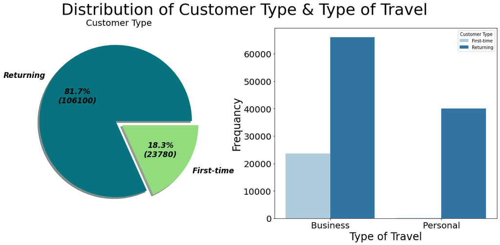

```python
fig, axes = plt.subplots(1, 2, figsize=(20,8))
fig.suptitle('Distribution of Customer Type & Type of Travel', size = 36)

Customer_Type = df['Customer Type'].value_counts()
axes[0].pie(Customer_Type.values, labels = Customer_Type.index, explode=[0.05, 0.05], shadow = True,
            autopct = lambda pct: func(pct, Customer_Type.values), colors = ['#08737f', '#92dc7e'],
            textprops = {'family':'sans-serif', 'fontsize':'xx-large', 'fontstyle':'italic', 'fontweight':'heavy'});
axes[0].set_title('Customer Type', fontsize = 20);

axes[1] = sns.countplot(data = df, x = 'Type of Travel', hue = 'Customer Type', palette = "Paired")
axes[1].set_xlabel('Type of Travel', size=24)
axes[1].set_ylabel('Frequancy', size=24)
axes[1].tick_params(labelsize = 20)
axes[1].spines['bottom'].set_color('black')
axes[1].spines['left'].set_color('black')
axes[1].spines['top'].set_color('black')
axes[1].spines['right'].set_color('black')
```

- Over 100K travelers (80%) have traveled before, so it's not their first flight
- While some Business travelers were on their first flight, almost all personal travelers had traveled before. I can suggest that Organizations may offer some persons the opportunity to have their first flight ever to do business.

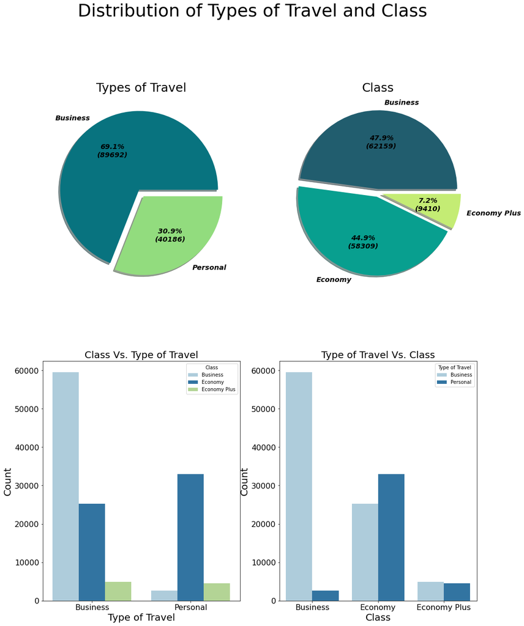

```python
fig, axes = plt.subplots(2, 2, figsize = (16,20))
fig.suptitle('Distribution of Types of Travel and Class', size = 36)

Type_of_Travel = df['Type of Travel'].value_counts()
axes[0][0].pie(Type_of_Travel.values, labels = Type_of_Travel.index, explode=[0.05, 0.05], shadow = True,
       autopct = lambda pct: func(pct, Type_of_Travel.values), colors = ['#08737f', '#92dc7e'],
       textprops = {'family':'sans-serif', 'fontsize':'x-large', 'fontstyle':'italic', 'fontweight':'heavy'});
axes[0][0].set_title('Types of Travel', fontsize = 25);

Class = df.Class.value_counts()
axes[0][1].pie(Class.values, labels = Class.index, explode=[0.05, 0.05, 0.05], shadow = True,
       autopct = lambda pct: func(pct, Class.values), colors = ['#215d6e', '#089f8f', '#c4ec74'],
       textprops = {'family':'sans-serif', 'fontsize':'x-large', 'fontstyle':'italic', 'fontweight':'heavy'});
axes[0][1].set_title('Class', fontsize = 25);

sns.countplot(data = df, x = 'Type of Travel', hue = 'Class', palette = "Paired", ax = axes[1][0])
axes[1][0].set_title('Class Vs. Type of Travel', fontsize = 20);
axes[1][0].set_xlabel('Type of Travel', size = 20)
axes[1][0].set_ylabel('Count', size = 20)
axes[1][0].tick_params(labelsize = 16)
axes[1][0].spines['bottom'].set_color('black')
axes[1][0].spines['left'].set_color('black')
axes[1][0].spines['top'].set_color('black')
axes[1][0].spines['right'].set_color('black')

sns.countplot(data = df, x = 'Class', hue = 'Type of Travel', palette = "Paired", ax = axes[1][1])
axes[1][1].set_title('Type of Travel Vs. Class', fontsize = 20);
axes[1][1].set_xlabel('Class', size = 20)
axes[1][1].set_ylabel('Count', size = 20)
axes[1][1].tick_params(labelsize = 16)
axes[1][1].spines['bottom'].set_color('black')
axes[1][1].spines['left'].set_color('black')
axes[1][1].spines['top'].set_color('black')
axes[1][1].spines['right'].set_color('black')
```

- Around 70% of travelers are traveling for business purposes, while 30% have personal reasons.
- Over 60K travelers are traveling in business class, while 58K booked an economy ticked, and only less than 10K booked an economy plus ticket.
- Business travelers travel in business class more than economy, while most personal travelers prefer economy class.
- Almost all business class users are business travelers.
- I think business travelers tend to travel in business class because their companies paid for the tickets for them, while personal travelers prefer economy class which they can afford it.

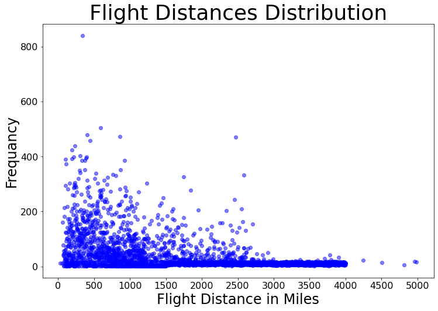

```python
fig, ax = plt.subplots(figsize = (12, 8))
Flight_Distance = df['Flight Distance'].value_counts().sort_index()
ax.scatter(Flight_Distance.index, Flight_Distance.values, color = 'blue', alpha = 0.5)
plt.title('Flight Distances Distribution', size = 36)
plt.xlabel('Flight Distance in Miles', size = 24)
plt.ylabel('Frequancy', size = 24)
plt.locator_params('x', nbins = 20)
plt.xticks(size = 16)
plt.yticks(size = 16)
plt.show()
```

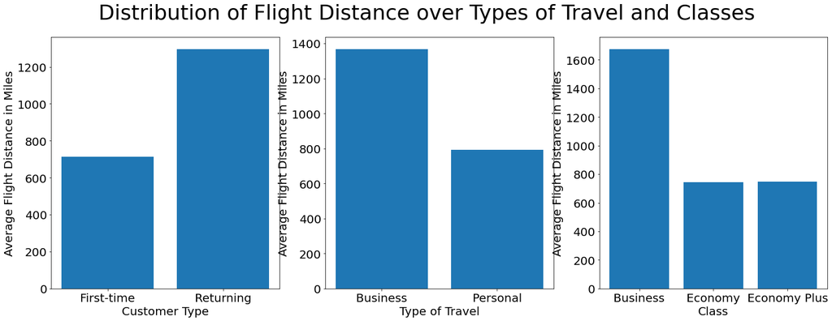

```python
fig, axes = plt.subplots(1, 3, figsize = (24,8))
fig.suptitle('Distribution of Flight Distance over Types of Travel and Classes', size = 36)

Customer_Type_Flight_Distance = df.groupby(['Customer Type'])['Flight Distance'].mean()
axes[0].bar(Customer_Type_Flight_Distance.index, Customer_Type_Flight_Distance.values)
axes[0].set_xlabel('Customer Type', size = 20)
axes[0].set_ylabel('Average Flight Distance in Miles', size = 20)
axes[0].tick_params(labelsize = 20)
axes[0].spines['bottom'].set_color('black')
axes[0].spines['left'].set_color('black')
axes[0].spines['top'].set_color('black')
axes[0].spines['right'].set_color('black')

Type_of_Travel_Flight_Distance = df.groupby(['Type of Travel'])['Flight Distance'].mean()
axes[1].bar(Type_of_Travel_Flight_Distance.index, Type_of_Travel_Flight_Distance.values)
axes[1].set_xlabel('Type of Travel', size = 20)
axes[1].set_ylabel('Average Flight Distance in Miles', size = 20)
axes[1].tick_params(labelsize = 20)
axes[1].spines['bottom'].set_color('black')
axes[1].spines['left'].set_color('black')
axes[1].spines['top'].set_color('black')
axes[1].spines['right'].set_color('black')

Class_Flight_Distance = df.groupby(['Class'])['Flight Distance'].mean()
axes[2].bar(Class_Flight_Distance.index, Class_Flight_Distance.values)
axes[2].set_xlabel('Class', size = 20)
axes[2].set_ylabel('Average Flight Distance in Miles', size = 20)
axes[2].tick_params(labelsize = 20)
axes[2].spines['bottom'].set_color('black')
axes[2].spines['left'].set_color('black')
axes[2].spines['top'].set_color('black')
axes[2].spines['right'].set_color('black')
```

- First-time travelers travel shorter distances than old travelers, almost the half distance on average.
- Business travelers travel longer distances than personal travelers. Maybe that's because they don't have the option to choose their destinations.
- Business class travelers travel on average more than twice the distance of economy or economy plus classes. In my opinion, long-distance travelers prefer to book a business class ticket to be more comfortable.

```python
df['Departure Delay'].value_counts()
```

```
0      73356
1       3682
2       2855
3       2535
4       2309
       ...
566        1
501        1
460        1
455        1
359        1
Name: Departure Delay, Length: 466, dtype: int64
```

```python
df['Arrival Delay'].value_counts()
```

```
0       72753
1        2747
2        2587
3        2442
4        2373
        ...
1011        1
386         1
624         1
355         1
412         1
Name: Arrival Delay, Length: 472, dtype: int64
```

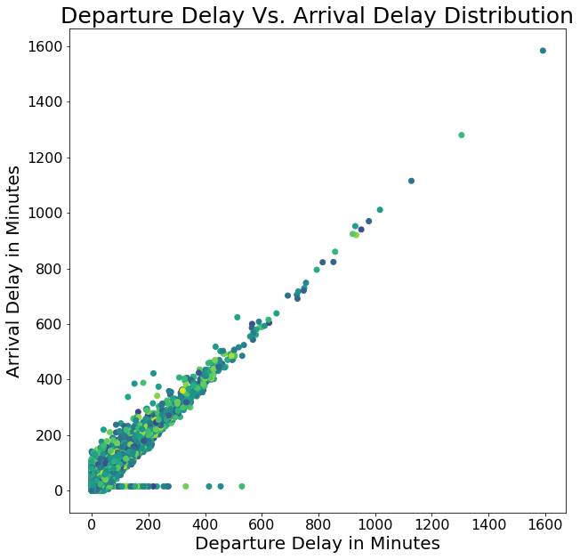

```python
fig, ax = plt.subplots(figsize = (10, 10))
ax.scatter(df['Departure Delay'], df['Arrival Delay'], c = df['Overall Satisfaction Points'])
plt.title('Departure Delay Vs. Arrival Delay Distribution', size = 25)
plt.xlabel('Departure Delay in Minutes', size = 20)
plt.ylabel('Arrival Delay in Minutes', size = 20)
plt.locator_params('x', nbins = 10)
plt.xticks(size = 16)
plt.yticks(size = 16)
plt.show()
```

- There's a linear proportional relationship between Departure Delay and Arrival Delay, and that's logical because flight duration is almost constant.

### ---------------------------------------- people's satisfaction is unreachable purpose ----------------------------------------

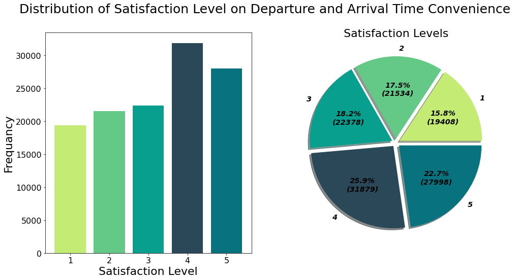

```python
fig, axes = plt.subplots(1, 2, figsize=(16,8))
fig.suptitle('Distribution of Satisfaction Level on Departure and Arrival Time Convenience', size = 25)

df_Time_Convenience = df[df['Departure and Arrival Time Convenience'] > 0]
Time_Convenience = df_Time_Convenience['Departure and Arrival Time Convenience'].value_counts().sort_index()

axes[0].bar(Time_Convenience.index, Time_Convenience.values, color = ['#c4ec74', '#64c987', '#089f8f', '#2a4858', '#08737f'])
axes[0].set_xlabel('Satisfaction Level', size = 22)
axes[0].set_ylabel('Frequancy', size = 22)
axes[0].tick_params(labelsize = 16)
axes[0].spines['bottom'].set_color('black')
axes[0].spines['left'].set_color('black')
axes[0].spines['top'].set_color('black')
axes[0].spines['right'].set_color('black')

axes[1].pie(Time_Convenience.values, labels = Time_Convenience.index, explode=[0.05, 0.05, 0.05, 0.05, 0.05],
       shadow = True, colors = ['#c4ec74', '#64c987', '#089f8f', '#2a4858', '#08737f'],
       autopct = lambda pct: func(pct, Time_Convenience.values),
       textprops = {'family':'sans-serif', 'fontsize':'x-large', 'fontstyle':'italic', 'fontweight':'heavy'});
axes[1].set_title('Satisfaction Levels', fontsize = 22);
```

```python
df_Time_Convenience['Departure and Arrival Time Convenience'].mean()
```

```
3.2234109043092882
```

- Average Satisfaction Level on Departure and Arrival Time Convenience is 3.22 out of 5

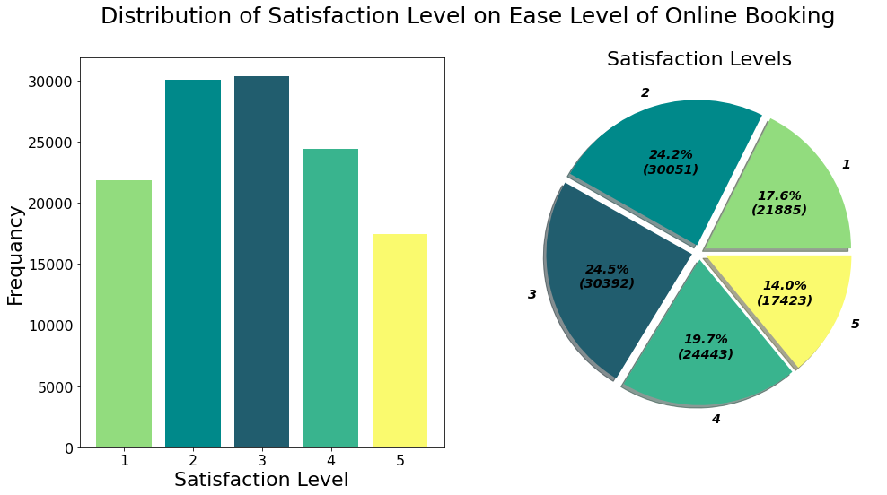

```python
fig, axes = plt.subplots(1, 2, figsize=(16,8))
fig.suptitle('Distribution of Satisfaction Level on Ease Level of Online Booking', size = 25)

df_Ease_of_Online_Booking = df[df['Ease of Online Booking'] > 0]
Ease_of_Online_Booking = df_Ease_of_Online_Booking['Ease of Online Booking'].value_counts().sort_index()

axes[0].bar(Ease_of_Online_Booking.index, Ease_of_Online_Booking.values, color = ['#92dc7e', '#00898a', '#215d6e', '#39b48e', '#fafa6e'])
axes[0].set_xlabel('Satisfaction Level', size = 22)
axes[0].set_ylabel('Frequancy', size = 22)
axes[0].tick_params(labelsize = 16)
axes[0].spines['bottom'].set_color('black')
axes[0].spines['left'].set_color('black')
axes[0].spines['top'].set_color('black')
axes[0].spines['right'].set_color('black')

axes[1].pie(Ease_of_Online_Booking.values, labels = Ease_of_Online_Booking.index, explode=[0.05, 0.05, 0.05, 0.05, 0.05],
       shadow = True, colors = ['#92dc7e', '#00898a', '#215d6e', '#39b48e', '#fafa6e'],
       autopct = lambda pct: func(pct, Ease_of_Online_Booking.values),
       textprops = {'family':'sans-serif', 'fontsize':'x-large', 'fontstyle':'italic', 'fontweight':'heavy'});
axes[1].set_title('Satisfaction Levels', fontsize = 22);
```

```python
df_Ease_of_Online_Booking['Ease of Online Booking'].mean()
```

```
2.883001336575468
```

- Average Satisfaction Level on Ease Level of Online Bookinge is 2.88 out of 5

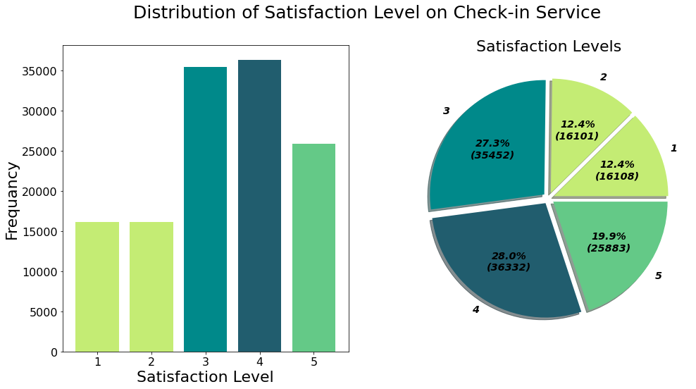

```python
fig, axes = plt.subplots(1, 2, figsize=(16,8))
fig.suptitle('Distribution of Satisfaction Level on Check-in Service', size = 25)

df_Check_in_Service = df[df['Check-in Service'] > 0]
Check_in_Service = df_Check_in_Service['Check-in Service'].value_counts().sort_index()

axes[0].bar(Check_in_Service.index, Check_in_Service.values, color = ['#c4ec74', '#c4ec74', '#00898a', '#215d6e', '#64c987'])
axes[0].set_xlabel('Satisfaction Level', size = 22)
axes[0].set_ylabel('Frequancy', size = 22)
axes[0].tick_params(labelsize = 16)
axes[0].spines['bottom'].set_color('black')
axes[0].spines['left'].set_color('black')
axes[0].spines['top'].set_color('black')
axes[0].spines['right'].set_color('black')

axes[1].pie(Check_in_Service.values, labels = Check_in_Service.index, explode=[0.05, 0.05, 0.05, 0.05, 0.05],
       shadow = True, colors = ['#c4ec74', '#c4ec74', '#00898a', '#215d6e', '#64c987'],
       autopct = lambda pct: func(pct, Check_in_Service.values),
       textprops = {'family':'sans-serif', 'fontsize':'x-large', 'fontstyle':'italic', 'fontweight':'heavy'});
axes[1].set_title('Satisfaction Levels', fontsize = 22);
```

```python
df_Check_in_Service['Check-in Service'].mean()
```

```
3.3062927802031123
```

- Average Satisfaction Level on Check-in Service is 3.31 out of 5

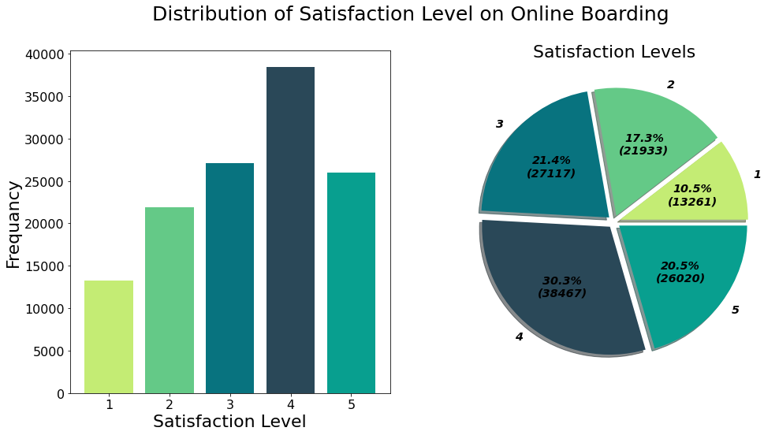

```python
fig, axes = plt.subplots(1, 2, figsize=(16,8))
fig.suptitle('Distribution of Satisfaction Level on Online Boarding', size = 25)

df_Online_Boarding = df[df['Online Boarding'] > 0]
Online_Boarding = df_Online_Boarding['Online Boarding'].value_counts().sort_index()

axes[0].bar(Online_Boarding.index, Online_Boarding.values, color = ['#c4ec74', '#64c987', '#08737f', '#2a4858', '#089f8f'])
axes[0].set_xlabel('Satisfaction Level', size = 22)
axes[0].set_ylabel('Frequancy', size = 22)
axes[0].tick_params(labelsize = 16)
axes[0].spines['bottom'].set_color('black')
axes[0].spines['left'].set_color('black')
axes[0].spines['top'].set_color('black')
axes[0].spines['right'].set_color('black')

axes[1].pie(Online_Boarding.values, labels = Online_Boarding.index, explode=[0.05, 0.05, 0.05, 0.05, 0.05],
       shadow = True, colors = ['#c4ec74', '#64c987', '#08737f', '#2a4858', '#089f8f'],
       autopct = lambda pct: func(pct, Online_Boarding.values),
       textprops = {'family':'sans-serif', 'fontsize':'x-large', 'fontstyle':'italic', 'fontweight':'heavy'});
axes[1].set_title('Satisfaction Levels', fontsize = 22);
```

```python
df_Online_Boarding['Online Boarding'].mean()
```

```
3.331640378548896
```

- Average Satisfaction Level on Online Boarding is 3.33 out of 5

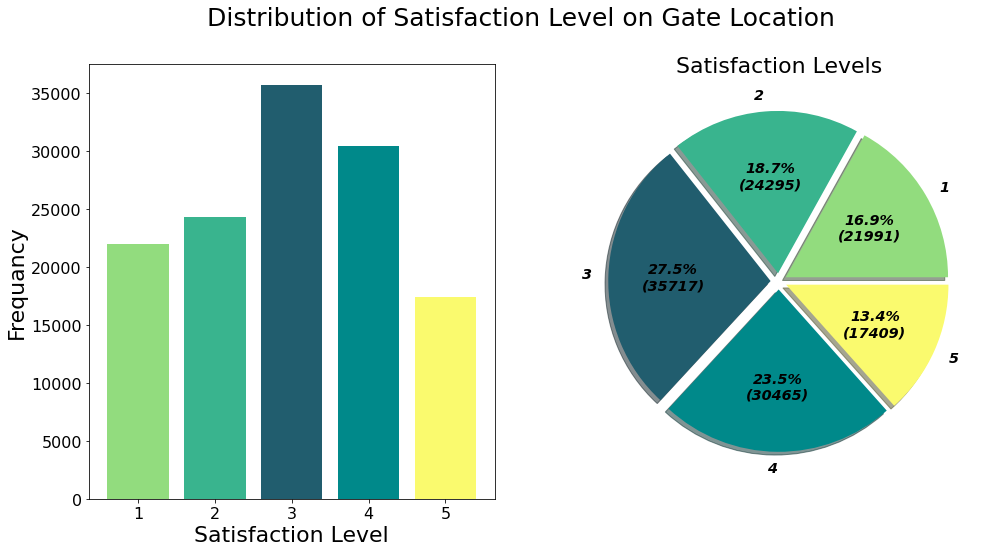

```python
fig, axes = plt.subplots(1, 2, figsize=(16,8))
fig.suptitle('Distribution of Satisfaction Level on Gate Location', size = 25)

df_Gate_Location = df[df['Gate Location'] > 0]
Gate_Location = df_Gate_Location['Gate Location'].value_counts().sort_index()

axes[0].bar(Gate_Location.index, Gate_Location.values, color = ['#92dc7e', '#39b48e', '#215d6e', '#00898a', '#fafa6e'])
axes[0].set_xlabel('Satisfaction Level', size = 22)
axes[0].set_ylabel('Frequancy', size = 22)
axes[0].tick_params(labelsize = 16)
axes[0].spines['bottom'].set_color('black')
axes[0].spines['left'].set_color('black')
axes[0].spines['top'].set_color('black')
axes[0].spines['right'].set_color('black')

axes[1].pie(Gate_Location.values, labels = Gate_Location.index, explode=[0.05, 0.05, 0.05, 0.05, 0.05],
       shadow = True, colors = ['#92dc7e', '#39b48e', '#215d6e', '#00898a', '#fafa6e'],
       autopct = lambda pct: func(pct, Gate_Location.values),
       textprops = {'family':'sans-serif', 'fontsize':'x-large', 'fontstyle':'italic', 'fontweight':'heavy'});
axes[1].set_title('Satisfaction Levels', fontsize = 22);
```

```python
df_Gate_Location['Gate Location'].mean()
```

```
2.976947774467004
```

- Average Satisfaction Level on Gate Location is 2.98 out of 5

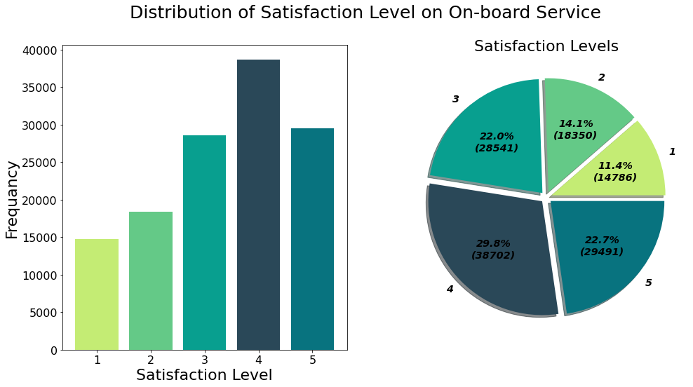

```python
fig, axes = plt.subplots(1, 2, figsize=(16,8))
fig.suptitle('Distribution of Satisfaction Level on On-board Service', size = 25)

df_On_board_Service = df[df['On-board Service'] > 0]
On_board_Service = df_On_board_Service['On-board Service'].value_counts().sort_index()

axes[0].bar(On_board_Service.index, On_board_Service.values, color = ['#c4ec74', '#64c987', '#089f8f', '#2a4858', '#08737f'])
axes[0].set_xlabel('Satisfaction Level', size = 22)
axes[0].set_ylabel('Frequancy', size = 22)
axes[0].tick_params(labelsize = 16)
axes[0].spines['bottom'].set_color('black')
axes[0].spines['left'].set_color('black')
axes[0].spines['top'].set_color('black')
axes[0].spines['right'].set_color('black')

axes[1].pie(On_board_Service.values, labels = On_board_Service.index, explode=[0.05, 0.05, 0.05, 0.05, 0.05],
       shadow = True, colors = ['#c4ec74', '#64c987', '#089f8f', '#2a4858', '#08737f'],
       autopct = lambda pct: func(pct, On_board_Service.values),
       textprops = {'family':'sans-serif', 'fontsize':'x-large', 'fontstyle':'italic', 'fontweight':'heavy'});
axes[1].set_title('Satisfaction Levels', fontsize = 22);
```

```python
df_On_board_Service['On-board Service'].mean()
```

```
3.3831530317613088
```

- Average Satisfaction Level on On-board Service is 3.38 out of 5

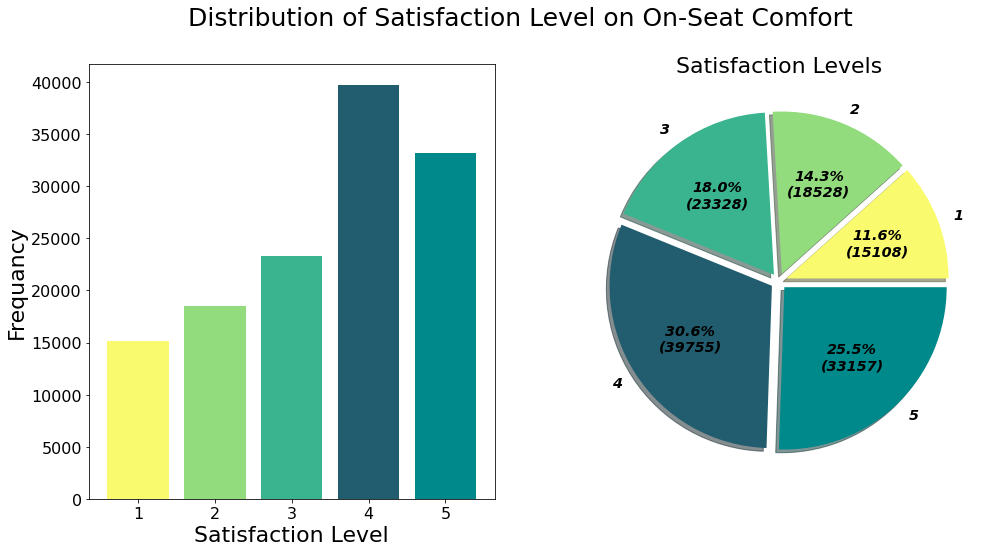

```python
fig, axes = plt.subplots(1, 2, figsize=(16,8))
fig.suptitle('Distribution of Satisfaction Level on On-Seat Comfort', size = 25)

df_Seat_Comfort = df[df['Seat Comfort'] > 0]
Seat_Comfort = df_Seat_Comfort['Seat Comfort'].value_counts().sort_index()

axes[0].bar(Seat_Comfort.index, Seat_Comfort.values, color = ['#fafa6e', '#92dc7e', '#39b48e', '#215d6e', '#00898a'])
axes[0].set_xlabel('Satisfaction Level', size = 22)
axes[0].set_ylabel('Frequancy', size = 22)
axes[0].tick_params(labelsize = 16)
axes[0].spines['bottom'].set_color('black')
axes[0].spines['left'].set_color('black')
axes[0].spines['top'].set_color('black')
axes[0].spines['right'].set_color('black')

axes[1].pie(Seat_Comfort.values, labels = Seat_Comfort.index, explode=[0.05, 0.05, 0.05, 0.05, 0.05],
       shadow = True, colors = ['#fafa6e', '#92dc7e', '#39b48e', '#215d6e', '#00898a'],
       autopct = lambda pct: func(pct, Seat_Comfort.values),
       textprops = {'family':'sans-serif', 'fontsize':'x-large', 'fontstyle':'italic', 'fontweight':'heavy'});
axes[1].set_title('Satisfaction Levels', fontsize = 22);
```

```python
df_Seat_Comfort['Seat Comfort'].mean()
```

```
3.441387753216455
```

- Average Satisfaction Level on On-Seat Comfort is 3.44 out of 5

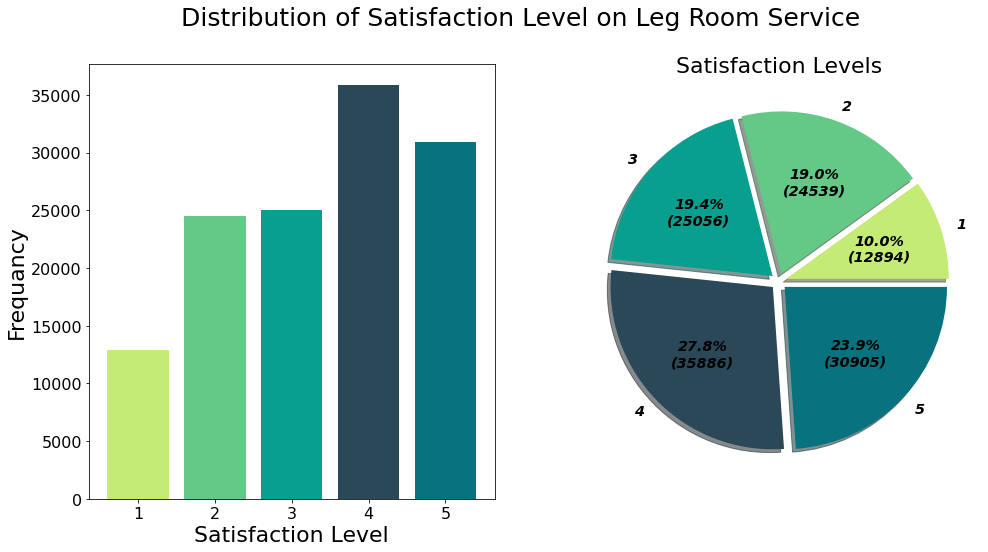

```python
fig, axes = plt.subplots(1, 2, figsize=(16,8))
fig.suptitle('Distribution of Satisfaction Level on Leg Room Service', size = 25)

df_Leg_Room_Service = df[df['Leg Room Service'] > 0]
Leg_Room_Service = df_Leg_Room_Service['Leg Room Service'].value_counts().sort_index()

axes[0].bar(Leg_Room_Service.index, Leg_Room_Service.values, color = ['#c4ec74', '#64c987', '#089f8f', '#2a4858', '#08737f'])
axes[0].set_xlabel('Satisfaction Level', size = 22)
axes[0].set_ylabel('Frequancy', size = 22)
axes[0].tick_params(labelsize = 16)
axes[0].spines['bottom'].set_color('black')
axes[0].spines['left'].set_color('black')
axes[0].spines['top'].set_color('black')
axes[0].spines['right'].set_color('black')

axes[1].pie(Leg_Room_Service.values, labels = Leg_Room_Service.index, explode=[0.05, 0.05, 0.05, 0.05, 0.05],
       shadow = True, colors = ['#c4ec74', '#64c987', '#089f8f', '#2a4858', '#08737f'],
       autopct = lambda pct: func(pct, Leg_Room_Service.values),
       textprops = {'family':'sans-serif', 'fontsize':'x-large', 'fontstyle':'italic', 'fontweight':'heavy'});
axes[1].set_title('Satisfaction Levels', fontsize = 22);
```

```python
df_Leg_Room_Service['Leg Room Service'].mean()
```

```
3.366377376587615
```

- Average Satisfaction Level on Leg Room Service is 3.37 out of 5

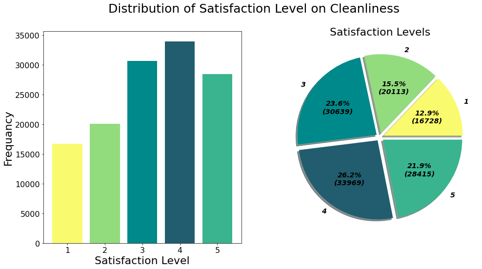

```python
fig, axes = plt.subplots(1, 2, figsize=(16,8))
fig.suptitle('Distribution of Satisfaction Level on Cleanliness', size = 25)

df_Cleanliness = df[df['Cleanliness'] > 0]
Cleanliness = df_Cleanliness['Cleanliness'].value_counts().sort_index()

axes[0].bar(Cleanliness.index, Cleanliness.values, color = ['#fafa6e', '#92dc7e', '#00898a', '#215d6e', '#39b48e'])
axes[0].set_xlabel('Satisfaction Level', size = 22)
axes[0].set_ylabel('Frequancy', size = 22)
axes[0].tick_params(labelsize = 16)
axes[0].spines['bottom'].set_color('black')
axes[0].spines['left'].set_color('black')
axes[0].spines['top'].set_color('black')
axes[0].spines['right'].set_color('black')

axes[1].pie(Cleanliness.values, labels = Cleanliness.index, explode=[0.05, 0.05, 0.05, 0.05, 0.05],
       shadow = True, colors = ['#fafa6e', '#92dc7e', '#00898a', '#215d6e', '#39b48e'],
       autopct = lambda pct: func(pct, Cleanliness.values),
       textprops = {'family':'sans-serif', 'fontsize':'x-large', 'fontstyle':'italic', 'fontweight':'heavy'});
axes[1].set_title('Satisfaction Levels', fontsize = 22);
```

```python
df_Cleanliness['Cleanliness'].mean()
```

```
3.286680116427702
```

- Average Satisfaction Level on Cleanliness is 3.29 out of 5

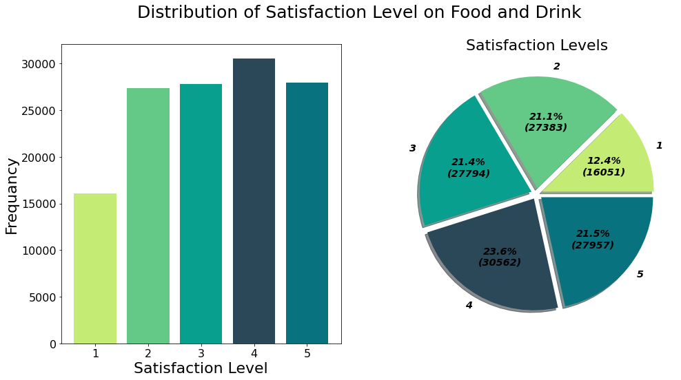

```python
fig, axes = plt.subplots(1, 2, figsize=(16,8))
fig.suptitle('Distribution of Satisfaction Level on Food and Drink', size = 25)

df_Food_and_Drink = df[df['Food and Drink'] > 0]
Food_and_Drink = df_Food_and_Drink['Food and Drink'].value_counts().sort_index()

axes[0].bar(Food_and_Drink.index, Food_and_Drink.values, color = ['#c4ec74', '#64c987', '#089f8f', '#2a4858', '#08737f'])
axes[0].set_xlabel('Satisfaction Level', size = 22)
axes[0].set_ylabel('Frequancy', size = 22)
axes[0].tick_params(labelsize = 16)
axes[0].spines['bottom'].set_color('black')
axes[0].spines['left'].set_color('black')
axes[0].spines['top'].set_color('black')
axes[0].spines['right'].set_color('black')

axes[1].pie(Food_and_Drink.values, labels = Food_and_Drink.index, explode=[0.05, 0.05, 0.05, 0.05, 0.05],
       shadow = True, colors = ['#c4ec74', '#64c987', '#089f8f', '#2a4858', '#08737f'],
       autopct = lambda pct: func(pct, Food_and_Drink.values),
       textprops = {'family':'sans-serif', 'fontsize':'x-large', 'fontstyle':'italic', 'fontweight':'heavy'});
axes[1].set_title('Satisfaction Levels', fontsize = 22);
```

```python
df_Food_and_Drink['Food and Drink'].mean()
```

```
3.2080340352067083
```

- Average Satisfaction Level on Food and Drink is 3.21 out of 5

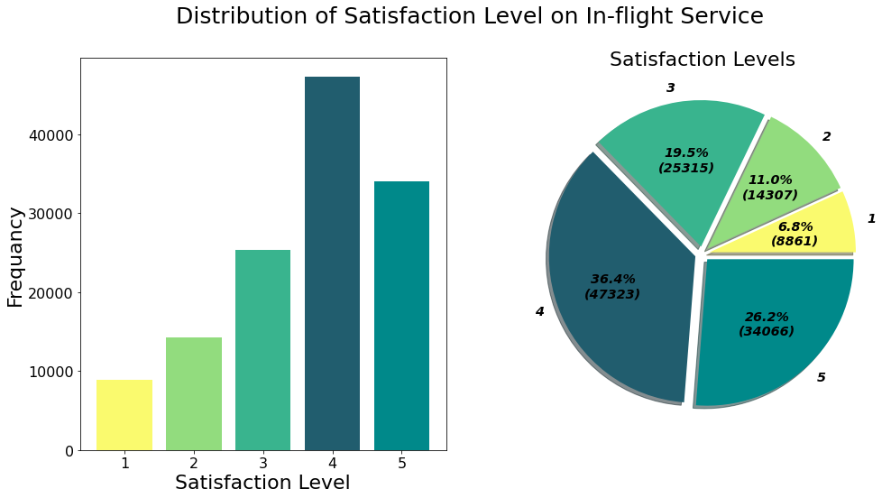

```python
fig, axes = plt.subplots(1, 2, figsize=(16,8))
fig.suptitle('Distribution of Satisfaction Level on In-flight Service', size = 25)

df_In_flight_Service = df[df['In-flight Service'] > 0]
In_flight_Service = df_In_flight_Service['In-flight Service'].value_counts().sort_index()

axes[0].bar(In_flight_Service.index, In_flight_Service.values, color = ['#fafa6e', '#92dc7e', '#39b48e', '#215d6e', '#00898a'])
axes[0].set_xlabel('Satisfaction Level', size = 22)
axes[0].set_ylabel('Frequancy', size = 22)
axes[0].tick_params(labelsize = 16)
axes[0].spines['bottom'].set_color('black')
axes[0].spines['left'].set_color('black')
axes[0].spines['top'].set_color('black')
axes[0].spines['right'].set_color('black')

axes[1].pie(In_flight_Service.values, labels = In_flight_Service.index, explode=[0.05, 0.05, 0.05, 0.05, 0.05],
       shadow = True, colors = ['#fafa6e', '#92dc7e', '#39b48e', '#215d6e', '#00898a'],
       autopct = lambda pct: func(pct, In_flight_Service.values),
       textprops = {'family':'sans-serif', 'fontsize':'x-large', 'fontstyle':'italic', 'fontweight':'heavy'});
axes[1].set_title('Satisfaction Levels', fontsize = 22);
```

```python
df_In_flight_Service['In-flight Service'].mean()
```

```
3.642333012512031
```

- Average Satisfaction Level on In-flight Service is 3.64 out of 5

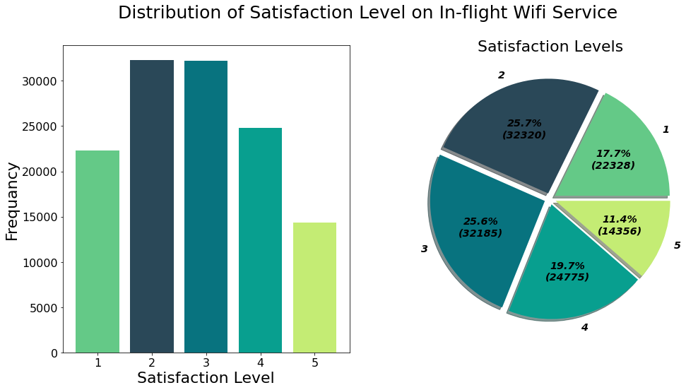

```python
fig, axes = plt.subplots(1, 2, figsize=(16,8))
fig.suptitle('Distribution of Satisfaction Level on In-flight Wifi Service', size = 25)

df_In_flight_Wifi_Service = df[df['In-flight Wifi Service'] > 0]
In_flight_Wifi_Service = df_In_flight_Wifi_Service['In-flight Wifi Service'].value_counts().sort_index()

axes[0].bar(In_flight_Wifi_Service.index, In_flight_Wifi_Service.values, color = ['#64c987', '#2a4858', '#08737f', '#089f8f', '#c4ec74'])
axes[0].set_xlabel('Satisfaction Level', size = 22)
axes[0].set_ylabel('Frequancy', size = 22)
axes[0].tick_params(labelsize = 16)
axes[0].spines['bottom'].set_color('black')
axes[0].spines['left'].set_color('black')
axes[0].spines['top'].set_color('black')
axes[0].spines['right'].set_color('black')

axes[1].pie(In_flight_Wifi_Service.values, labels = In_flight_Wifi_Service.index, explode=[0.05, 0.05, 0.05, 0.05, 0.05],
       shadow = True, colors = ['#64c987', '#2a4858', '#08737f', '#089f8f', '#c4ec74'],
       autopct = lambda pct: func(pct, In_flight_Wifi_Service.values),
       textprops = {'family':'sans-serif', 'fontsize':'x-large', 'fontstyle':'italic', 'fontweight':'heavy'});
axes[1].set_title('Satisfaction Levels', fontsize = 22);
```

```python
df_In_flight_Wifi_Service['In-flight Wifi Service'].mean()
```

```
2.813526086818456
```

- Average Satisfaction Level on In-flight Wifi Service is 2.81 out of 5

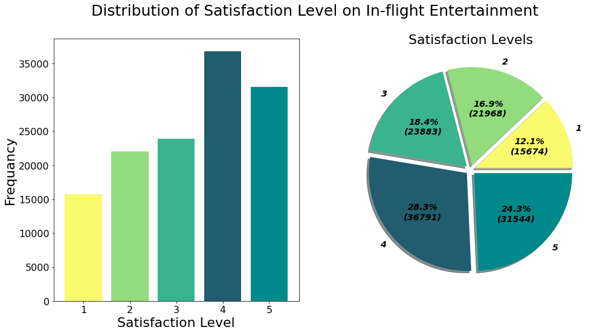

```python
fig, axes = plt.subplots(1, 2, figsize=(16,8))
fig.suptitle('Distribution of Satisfaction Level on In-flight Entertainment', size = 25)

df_In_flight_Entertainment = df[df['In-flight Entertainment'] > 0]
In_flight_Entertainment = df_In_flight_Entertainment['In-flight Entertainment'].value_counts().sort_index()

axes[0].bar(In_flight_Entertainment.index, In_flight_Entertainment.values, color = ['#fafa6e', '#92dc7e', '#39b48e', '#215d6e', '#00898a'])
axes[0].set_xlabel('Satisfaction Level', size = 22)
axes[0].set_ylabel('Frequancy', size = 22)
axes[0].tick_params(labelsize = 16)
axes[0].spines['bottom'].set_color('black')
axes[0].spines['left'].set_color('black')
axes[0].spines['top'].set_color('black')
axes[0].spines['right'].set_color('black')

axes[1].pie(In_flight_Entertainment.values, labels = In_flight_Entertainment.index, explode=[0.05, 0.05, 0.05, 0.05, 0.05],
       shadow = True, colors = ['#fafa6e', '#92dc7e', '#39b48e', '#215d6e', '#00898a'],
       autopct = lambda pct: func(pct, In_flight_Entertainment.values),
       textprops = {'family':'sans-serif', 'fontsize':'x-large', 'fontstyle':'italic', 'fontweight':'heavy'});
axes[1].set_title('Satisfaction Levels', fontsize = 22);
```

```python
df_In_flight_Entertainment['In-flight Entertainment'].mean()
```

```
3.3585421447382604
```

- Average Satisfaction Level on In-flight Entertainment is 3.36 out of 5

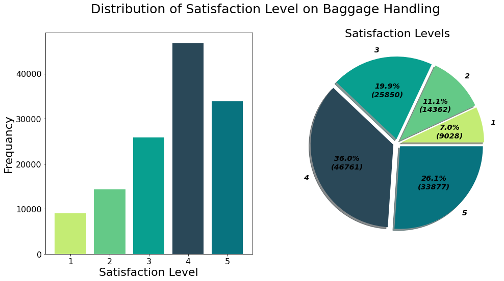

```python
fig, axes = plt.subplots(1, 2, figsize=(16,8))
fig.suptitle('Distribution of Satisfaction Level on Baggage Handling', size = 25)

df_Baggage_Handling = df[df['Baggage Handling'] > 0]
Baggage_Handling = df_Baggage_Handling['Baggage Handling'].value_counts().sort_index()

axes[0].bar(Baggage_Handling.index, Baggage_Handling.values, color = ['#c4ec74', '#64c987', '#089f8f', '#2a4858', '#08737f'])
axes[0].set_xlabel('Satisfaction Level', size = 22)
axes[0].set_ylabel('Frequancy', size = 22)
axes[0].tick_params(labelsize = 16)
axes[0].spines['bottom'].set_color('black')
axes[0].spines['left'].set_color('black')
axes[0].spines['top'].set_color('black')
axes[0].spines['right'].set_color('black')

axes[1].pie(Baggage_Handling.values, labels = Baggage_Handling.index, explode=[0.05, 0.05, 0.05, 0.05, 0.05],
       shadow = True, colors = ['#c4ec74', '#64c987', '#089f8f', '#2a4858', '#08737f'],
       autopct = lambda pct: func(pct, Baggage_Handling.values),
       textprops = {'family':'sans-serif', 'fontsize':'x-large', 'fontstyle':'italic', 'fontweight':'heavy'});
axes[1].set_title('Satisfaction Levels', fontsize = 22);
```

```python
df_Baggage_Handling['Baggage Handling'].mean()
```

```
3.632114259316292
```

- Average Satisfaction Level on Baggage Handling is 3.63 out of 5

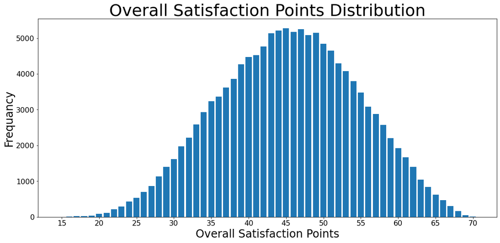

```python
Overall_Satisfaction_Points = df['Overall Satisfaction Points'].value_counts().sort_index()
fig, ax = plt.subplots(figsize = (18, 8))
ax.bar(Overall_Satisfaction_Points.index, Overall_Satisfaction_Points.values)
plt.title('Overall Satisfaction Points Distribution', size = 36)
plt.xlabel('Overall Satisfaction Points', size = 24)
plt.ylabel('Frequancy', size = 24)
plt.locator_params('x', nbins = 20)
plt.xticks(size = 16)
plt.yticks(size = 16)
plt.show()
```

```python
df['Overall Satisfaction Points'].mean()
```

```
45.37774099168463
```

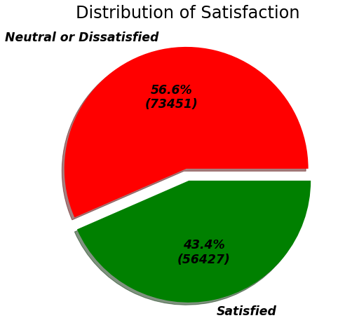

```python
Satisfaction = df.Satisfaction.value_counts()
fig, ax = plt.subplots(figsize = (12, 8))
ax.pie(Satisfaction.values, labels = Satisfaction.index, explode=[0.05, 0.05], shadow = True, colors = ['r', 'g'],
       autopct = lambda pct: func(pct, Satisfaction.values),
       textprops = {'family':'sans-serif', 'fontsize':'xx-large', 'fontstyle':'italic', 'fontweight':'heavy'})
plt.title('Distribution of Satisfaction', size = 24)
plt.show()
```

```python
df_Satisfaction = df[['Departure and Arrival Time Convenience', 'Ease of Online Booking', 'Check-in Service', 'Online Boarding',
                      'Gate Location', 'On-board Service', 'Seat Comfort', 'Leg Room Service', 'Cleanliness', 'Food and Drink',
                      'In-flight Service', 'In-flight Wifi Service', 'In-flight Entertainment', 'Baggage Handling',
                      'Overall Satisfaction Points']]
```

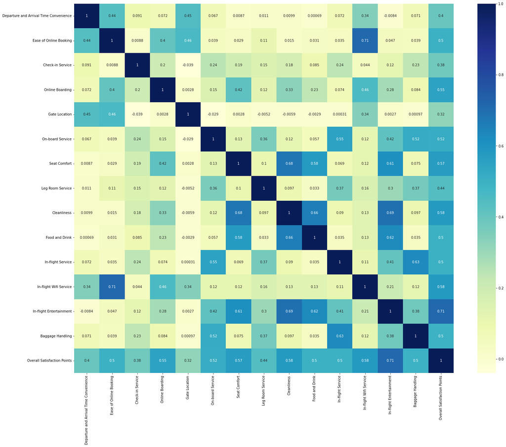

```python
# Plotting a heatmap to show the correlation between features
plt.figure(figsize = (25,20))
sns.heatmap(df_Satisfaction.corr(), annot = True , cmap = "YlGnBu");
```

```python
# Encoding categorical data
from sklearn.preprocessing import LabelEncoder
le = LabelEncoder()
```

```python
# Encoding Gender column
df['Gender'] = le.fit_transform(df['Gender'])
```

```python
# Encoding Customer Type column
df['Customer Type'] = le.fit_transform(df['Customer Type'])
```

```python
# Encoding Type of Travel column
df['Type of Travel'] = le.fit_transform(df['Type of Travel'])
```

```python
# Encoding Class column
df['Class'] = le.fit_transform(df['Class'])
```

```python
# Encoding Satisfaction column
df['Satisfaction'] = le.fit_transform(df['Satisfaction'])
```

```python
# Assigning independent values to array X, and dependant values to array y
X = df.iloc[:, :-1].values
y = df.iloc[:, -1].values
```

```python
# Splitting the dataset into the training set and test set
from sklearn.model_selection import train_test_split
X_train, X_test, y_train, y_test = train_test_split(X, y, test_size = 0.25)
```

```python
# Applying feature scaling to independent values
from sklearn.preprocessing import StandardScaler
sc = StandardScaler()
X_train = sc.fit_transform(X_train)
X_test = sc.transform(X_test)
```

# Logistic Regression Model

```python
# Training the Logistic Regression Model on the training set
from sklearn.linear_model import LogisticRegression
classifier = LogisticRegression()
classifier.fit(X_train, y_train)
```

```
LogisticRegression()
```

```python
# Predicting the test set results
y_pred = classifier.predict(X_test)
np.set_printoptions(precision=2)
print(np.concatenate((y_pred.reshape(len(y_pred),1), y_test.reshape(len(y_test),1)),1))
```

```
[[1 1]
 [1 1]
 [1 1]
 ...
 [0 0]
 [0 0]
 [1 1]]
```

```python
# Evaluating the model Performance on the training set
lrtrain = classifier.score(X_train , y_train)
lrtrain
```

```
0.8746124627861616
```

```python
# Evaluating the model Performance on the test set
lrtest = classifier.score(X_test , y_test)
lrtest
```

```
0.8746843239913766
```

```python
# Making the Confusion Matrix
from sklearn.metrics import confusion_matrix, accuracy_score
y_pred = classifier.predict(X_test)
cm = confusion_matrix(y_test, y_pred)
print(cm)
accuracy_score(y_test, y_pred)
```

```
[[16450  1758]
 [ 2311 11951]]
```

```
0.8746843239913766
```

```python
# Creating a new data frame containing the predicted and actual values
lr_acc = pd.DataFrame(np.concatenate((y_pred.reshape(len(y_pred),1), y_test.reshape(len(y_test),1)),1),
                      columns = ['Predicted', 'Actual'])
```

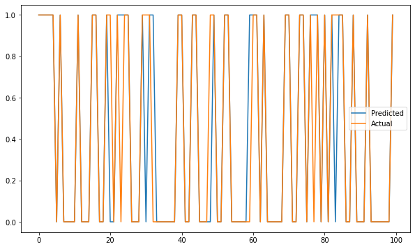

```python
# Plotting a graph showing the comparison between predicted and actual values
plt.figure(figsize = (10,6))
plt.plot(lr_acc[:100])
plt.legend(['Predicted' , 'Actual']);
```

# K Nearest Neighbors Classifier Model

```python
# Training the K Nearest Neighbors Classifier Model on the training set
from sklearn.neighbors import KNeighborsClassifier
classifier = KNeighborsClassifier(n_neighbors = 5, metric = 'minkowski', p = 2)
classifier.fit(X_train, y_train)
```

```
KNeighborsClassifier()
```

```python
# Predicting the test set results
y_pred = classifier.predict(X_test)
np.set_printoptions(precision=2)
print(np.concatenate((y_pred.reshape(len(y_pred),1), y_test.reshape(len(y_test),1)),1))
```

```
[[1 1]
 [1 1]
 [1 1]
 ...
 [0 0]
 [0 0]
 [1 1]]
```

```python
# Evaluating the model Performance on the training set
knntrain = classifier.score(X_train , y_train)
knntrain
```

```
0.949738219895288
```

```python
# Evaluating the model Performance on the test set
knntest = classifier.score(X_test , y_test)
knntest
```

```
0.929781336618417
```

```python
# Making the Confusion Matrix
y_pred = classifier.predict(X_test)
cm = confusion_matrix(y_test, y_pred)
print(cm)
accuracy_score(y_test, y_pred)
```

```
[[17569   639]
 [ 1641 12621]]
```

```
0.929781336618417
```

```python
# Creating a new data frame containing the predicted and actual values
knn_acc = pd.DataFrame(np.concatenate((y_pred.reshape(len(y_pred),1), y_test.reshape(len(y_test),1)),1),
                       columns = ['Predicted', 'Actual'])
```

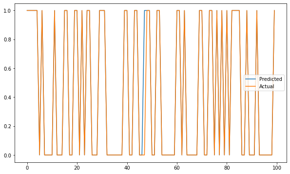

```python
# Plotting a graph showing the comparison between predicted and actual values
plt.figure(figsize = (10,6))
plt.plot(knn_acc[:100])
plt.legend(['Predicted' , 'Actual']);
```

# Support Vector Machine Classifier Model

```python
# Training the Support Vector Machine Classifier Model on the training set
from sklearn.svm import SVC
classifier = SVC(kernel = 'linear', random_state = 0)
classifier.fit(X_train, y_train)
```

```
SVC(kernel='linear', random_state=0)
```

```python
# Evaluating the model Performance on the training set
svmtrain = classifier.score(X_train , y_train)
svmtrain
```

```
0.8761934093008932
```

```python
# Evaluating the model Performance on the test set
svmtest = classifier.score(X_test , y_test)
svmtest
```

```
0.8765629812134278
```

```python
# Making the Confusion Matrix
y_pred = classifier.predict(X_test)
cm = confusion_matrix(y_test, y_pred)
print(cm)
accuracy_score(y_test, y_pred)
```

```
[[16607  1601]
 [ 2407 11855]]
```

```
0.8765629812134278
```

```python
# Creating a new data frame containing the predicted and actual values
svm_acc = pd.DataFrame(np.concatenate((y_pred.reshape(len(y_pred),1), y_test.reshape(len(y_test),1)),1),
                      columns = ['Predicted', 'Actual'])
```

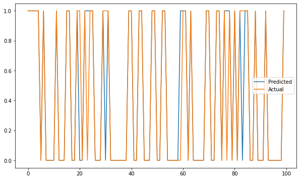

```python
# Plotting a graph showing the comparison between predicted and actual values
plt.figure(figsize = (10,6))
plt.plot(svm_acc[:100])
plt.legend(['Predicted' , 'Actual']);
```

# Naive Bayes Classifier Model

```python
# Training the Naive Bayes Classifier Model on the training set
from sklearn.naive_bayes import GaussianNB
classifier = GaussianNB()
classifier.fit(X_train, y_train)
```

```
GaussianNB()
```

```python
# Evaluating the model Performance on the training set
nbtrain = classifier.score(X_train , y_train)
nbtrain
```

```
0.8592341648701365
```

```python
# Evaluating the model Performance on the test set
nbtest = classifier.score(X_test , y_test)
nbtest
```

```
0.8587619340930089
```

```python
# Making the Confusion Matrix
y_pred = classifier.predict(X_test)
cm = confusion_matrix(y_test, y_pred)
print(cm)
accuracy_score(y_test, y_pred)
```

```
[[16287  1921]
 [ 2665 11597]]
```

```
0.8587619340930089
```

```python
# Creating a new data frame containing the predicted and actual values
nb_acc = pd.DataFrame(np.concatenate((y_pred.reshape(len(y_pred),1), y_test.reshape(len(y_test),1)),1),
                      columns = ['Predicted', 'Actual'])
```

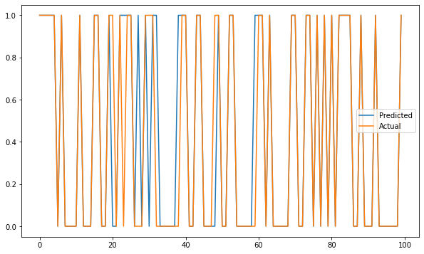

```python
# Plotting a graph showing the comparison between predicted and actual values
plt.figure(figsize = (10,6))
plt.plot(nb_acc[:100])
plt.legend(['Predicted' , 'Actual']);
```